# Tarea 1 - Simulación

Alexander A. Ramírez M. (alexanderramirez.me)

13 de Julio, 2016

1. Si $x_0=5$ y

$$x_n = 3x_{n-1}\text{ mod }150$$

determine $x_1,x_2,....,x_{10}$.

El generador congruencial mixto sigue la fórmula siguiente:
$$x_n=(a x_{n-1}+c)\text{ mod }m$$

Para $n\ge 1$, $x_0>0$, $a>0$, $c\ge 0$, $m>x_0$, $m>a$ y $m>c$.

El generador congruencial multiplicativo es un caso particular del mixto con $c=0$.

$$x_n=a x_{n-1}\text{ mod }m$$

Primero vamos a crear una función que calcule los $n$ valores de un generador de números pseudoaleatorios congruencial mixto.

```r
rcongr <- function(n,a,c,m,x0, pseudo=FALSE) {
  #Primero asignamos la semilla del generador x_0
  result<-c(x0)
  #Hacemos un loop con n pasos
  for(i in 1:n) {
    #Añadimos un nuevo valor al arreglo con el generador congruencial mixto
    result<-append(result, (a*result[i]+c) %% m)
  }
  #Si pseudo=TRUE entonces devuelve el vector de números pseudo aleatorios
  if (pseudo) {
    return(result[1:n+1]/m)
  #Si pseudo=FALSE entonces devuelve el vector de números enteros aleatorios
  } else {
    return(result[1:n+1])
  }
}
```

Ahora vamos a llamar la función recién creada con los parámetros respectivos donde $n=10$, $a=3$, $c=0$, $m=150$ y $x_0=5$ y generemos $x_1, x_2, \ldots , x_{10}$ solicitado:

```r
rcongr(10,3,0,150,5)
```

```
##  [1]  15  45 135 105  15  45 135 105  15  45
```

Este generador tiene un período igual a 4.

2. Si $x_0=3$ y

$$x_n = (5x_{n-1}+7)\text{ mod }200$$

determine $x_1,x_2,....,x_{10}$.

De forma similar al ejercicio anterior vamos a utilizar la función que calcula los $n$ valores de un generador de números pseudoaleatorios congruencial mixto.

```r
rcongr(10,5,7,200,3)
```

```
##  [1]  22 117 192 167  42  17  92  67 142 117
```

Este generador tiene un período igual a 8.

En la función dejamos un parámetro `pseudo=FALSE` que indica si se debe dividir cada $x_n$ entre $m$ para generar los números pseudoaleatorios. A continuación el resultado con los mismos parámetros, excepto por el parámetro `pseudo` que ahora es `pseudo=TRUE`.

```r
rcongr(10,3,0,150,5,pseudo = TRUE)
```

```
##  [1] 0.1 0.3 0.9 0.7 0.1 0.3 0.9 0.7 0.1 0.3
```

```r
rcongr(10,5,7,200,3,pseudo = TRUE)
```

```
##  [1] 0.110 0.585 0.960 0.835 0.210 0.085 0.460 0.335 0.710 0.585
```

3. Para $U_1, U_2, ...$ variables aleatorias uniformes en $(0,1)$, definimos

$$N = mín\{n: \sum_{i=1}^n U_i > 1 \}$$

Es decir, $N$ es igual a la cantidad de números aleatorios que deben sumarse para extender a 1.

1. Estime $\mathbb{E}(N)$ generando $100$ valores de $N$.
2. Estime $\mathbb{E}(N)$ generando $1000$ valores de $N$.
3. Estime $\mathbb{E}(N)$ generando $10000$ valores de $N$.
4. ¿Cuál cree que sea el valor de $\mathbb{E}(N)$.

```r
#set.seed(12345679)
generate_N<-function(n) { # Un sólo parámetro n = número de valores de N a generar
  N<-c() # Inicializamos el vector de valores de N vacio
  UnifV<-runif(n*3) # Generamos n*3 realizaciones de U_n
  uv_index<-1 # Este es el índice para recorrer el vector de U_n
  for(i in (1:n)) { # Hacemos el proceso de generar N, n veces
    sum_U<-0 # Inicializamos la suma en cada iteración
    n<-0 # Inicializamos el contador de n cada iteración
    while (sum_U<=1) { # Mientras la suma sema menor o igual a 1 seguimos
      sum_U<-sum_U + UnifV[uv_index] # Realizamos la suma de las U_n
      n<-n+1 # Incrementamos el n
      uv_index<-uv_index+1 # Incrementamos el índice del vector de U_n
    }
    N<-append(N,n) # Añadimos el n al vector de N
  }
  return(N)
}
```

1. Para generar $100$ valores de $N$ utilizamos la función que acabamos de hacer con $n=100$ como parámetro, el resultado es el siguiente:

```r
N100<-generate_N(100) # Generamos el vector con 100 valores de N
N100
```

```
##   [1] 2 2 2 2 3 2 2 2 2 3 4 2 2 3 2 3 5 2 3 3 4 3 2 2 3 3 3 2 6 2 2 3 2 2 3
##  [36] 2 2 4 2 3 2 2 2 2 2 3 2 3 2 4 2 2 3 2 4 2 3 3 2 3 2 4 3 2 2 4 3 2 2 3
##  [71] 2 5 4 2 2 3 2 2 2 3 5 3 2 2 2 3 2 4 3 4 3 2 2 4 2 2 3 2 2 3
```

```r
mean(N100) # Calculamos la esperanza de los valores de N, E(N)
```

```
## [1] 2.65
```

2. De la misma manera para generar los $1000$ valores utilizamos de nuevo la función `generate_N` con parámetro $n=1000$ y calculamos su promedio.

```r
N1000<-generate_N(1000)
mean(N1000)
```

```
## [1] 2.714
```

3. Ahora utilizamos $n=10000$ e invocamos `generate_N` de nuevo.

```r
N10000<-generate_N(10000)
mean(N10000)
```

```
## [1] 2.7056
```

4. Creo que es entre $2$ y $3$. Pero más allá de la creencia la media de una serie de variables aleatorias uniformes en $(0,1)$ debe tender a $\frac{1}{2}=0,5$ por lo que necesitamos al menos dos variables para que la suma sea mayor estricta que $1$.

```r
mean(runif(100))
```

```
## [1] 0.5429683
```

```r
mean(runif(1000))
```

```
## [1] 0.5040966
```

```r
mean(runif(10000))
```

```
## [1] 0.4989101
```

Vamos a estudiar la media $N$ generando $100$ variables $\mu_N$ con la media de $100$ valores de $N$.

```r
mean_N_vector<-c()
for (i in 1:100) {
  mean_N_vector<-append(mean_N_vector,mean(generate_N(100)))
}
mean_N_vector
```

```
##   [1] 2.55 2.79 2.79 2.60 2.77 2.66 2.72 2.88 2.77 2.58 2.80 2.87 2.74 2.44
##  [15] 2.69 2.90 2.63 2.81 2.70 2.88 2.73 2.66 2.57 2.70 2.74 2.74 2.91 2.65
##  [29] 2.84 2.87 2.85 2.73 2.48 2.76 2.76 2.51 2.58 2.43 2.64 2.64 2.72 2.65
##  [43] 2.92 2.76 2.68 2.83 2.61 2.72 2.62 2.76 2.71 2.54 2.75 2.75 2.80 2.73
##  [57] 2.79 2.70 2.81 2.82 2.67 2.59 2.82 2.73 2.72 2.65 2.84 2.68 2.74 2.66
##  [71] 2.73 2.63 2.59 2.75 2.67 2.62 2.64 2.70 2.94 2.67 2.59 2.86 2.69 2.67
##  [85] 2.61 2.68 2.66 2.79 2.63 2.63 2.68 2.51 2.67 2.72 2.84 2.83 2.69 2.68
##  [99] 2.75 2.59
```

```r
mean(mean_N_vector)
```

```
## [1] 2.7084
```

```r
sd(mean_N_vector)
```

```
## [1] 0.1050418
```

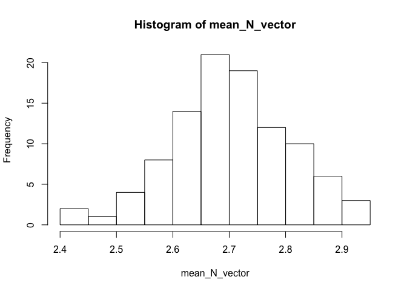

```r
hist(mean_N_vector)
```

```r
t.test(mean_N_vector,mu=2.71,conf.level = 0.99)
```

```
##
##  One Sample t-test
##
## data:  mean_N_vector
## t = -0.15232, df = 99, p-value = 0.8792
## alternative hypothesis: true mean is not equal to 2.71
## 99 percent confidence interval:
##  2.680812 2.735988
## sample estimates:
## mean of x
##    2.7084
```

Definamos $H_o: \mu=2,71$ con un nivel de confianza de 0.99. Nuestro nivel de significancia es $\alpha=0,01$. Si el p-valor es menor que $\alpha$, $p-value<\alpha$, entonces rechazamos $H_o$ y nos quedamos con $H_a: \mu\ne 2,71$.

4. Describa una forma alternativa de generar variables aleatorias binomiales según la descripción del libro. *Simulación*, página 53, Escriba un código en R de dicho algoritmo.
5. Escriba un programa en **R** para generar $n$ valores a partir de la función de masa de probabilidad $p_1=\frac{1}{3}$, $p_2=\frac{2}{3}$.
1. Sean $n=100$, ejecute el programa y determine la proporción de valores que sean iguales a 1.
2. Repita (a) con $n=1000$.
3. Repeta (a) con $n=10000$.

**Fecha de entrega:** Martes 19 de Julio de 2016.